# NEX-GDDP-CMIP6

## Summary Description

NASA’S Earth Exchange Global Daily Downscaled Projections (NEX-GDDP-CMIP6) is an ensemble of global climate model simulations bias-adjusted by NASA. It downscales 9 variables from 35 climate models over a historical period (1950–2014) and four future emissions pathways (SSP1-2.6, SSP2-4.5, SSP3-7.0, SSP5-8.5) using the bias correction/spatial disaggregation (BCSD) bias-adjustment method. The reference dataset used is the Global Meteorological Forcing Dataset (GMFD). A detailed description of the dataset is available in Thrasher *et al.* (2022).

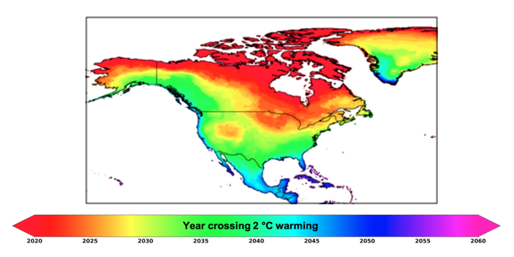

Spatial pattern of years exceeding 2˚C warming (baseline 1950-1979) from the NEX-GDDP-CMIP6 ensemble over North America (source: [NASA Earth Exchange](https://www.nasa.gov/nasa-earth-exchange-nex/gddp/downscaled-climate-projections-nex-gddp-cmip6/))

## Dataset Characteristics

- **Current version:** [v2.0](https://www.nccs.nasa.gov/sites/default/files/NEX-GDDP-CMIP6-v2-Tech_Note.pdf)
- **Available variables:** temperature, precipitation, wind, humidity, longwave and shortwave radiation (see variables section below)
- **Temporal coverage**: 1950–2100
- **Temporal resolution:** daily
- **Spatial coverage:** global
- **Spatial resolution:** 0.25 degree
- **Data type:** Bias-adjusted climate projections
- **Data format:** netCDF and Cloud optimized GeoTIFF (COG)
- **Web references:**  
  [NASA website](https://www.nccs.nasa.gov/services/data-collections/land-based-products/nex-gddp-cmip6)
- **Reference:**  
  Thrasher *et al.* (2022)
- **Contact:** Dr. Bridget Thrasher and Dr. Ian Brosnan, NASA NEX  
  Data Support: Nasa Center for Climate Simulation (NCCS) Support

## When to use NEX-GDDP-CMIP6

- When you need **CMIP-based, bias-adjusted future climate projections** at a global scale
- When you need **bias-adjusted wind, humidity and radiation data** in addition to temperature and precipitation
- When you need **downscaled climate data** suitable for **impact studies at medium spatial resolution** that **better represent local processes** (e.g., topography, coastlines) than global models
- When you need climate projections under **four future emissions pathways (SSPs)**
- When you need **scenario-based projections** with improved agreement with a global reference dataset
- When you want to avoid performing **bias correction and post-processinng workflows** on CMIP6 data, particularly outside of Canada

## Strengths and Limitations

### Key Strengths of NEX-GDDP-CMIP6

| Strength | Description |
| --- | --- |
| **Large multi-model ensemble** | Makes use of a large number of climate models, which allows to sample the (structural) uncertainty associated with climate projections. |
| **Multiple emission scenarios** | Simulations driven by four different emission scenarios were processed to span a wide range of possible futures. |
| **Multiple variables** | Nine climate variables are available. |

### Key Limitations of NEX-GDDP-CMIP6

| Limitation | Description |
| --- | --- |
| **Lower resolution** | The resolution is relatively low compared to other bias-adjusted datasets, although it is improved compared to the GCM’s resolution. |
| **Few references** | There is little documented experience using this dataset over Canada. |

## Expert Guidance

**None(click to expand)**

NEX-GDDP-CMIP6 stands out from other bias-adjusted datasets by providing data for the entire globe as opposed to a limited domain. It also provides 9 different variables: mean temperature, maximum temperature, minimum temperature, precipitation, relative humidity, specific humidity, longwave downwelling radiation, shortwave downwelling radiation, near surface wind speed.

The dataset is composed of 35 different models, but not all models are available for all variables and emissions scenarios. Users should be careful when comparing ensembles that have a different composition.

The trend of the original simulations is preserved in the bias-adjusted product. This means that “the hot model problem” (Hausfather *et al.* (2022)), i.e. the over representation of models that warm up too quickly, will also be present for this dataset. See the “Expert Guidance” section on the CMIP6 data page.

The dataset might not be realistic over smaller islands as the reference dataset (Global Meteorological Forcing Dataset - GMFD; Department of Civil and Environmental Engineering, Princeton University (2006)) has not been validated over oceans.

The dataset is accompanied by the following warning: “*This dataset is intended for use in scientific research only, and use of this dataset for other purposes, such as commercial applications, and engineering or design studies is not recommended without consultation with a qualified expert.*”

Because there are very few studies that have looked at this dataset specifically over Canada in the literature, the quality and limitations of the dataset over the country have not been well established. Users are strongly encouraged to validate the data for their region before using them.

The dataset includes the high emissions scenario SSP5-8.5 which can be considered unlikely to realize under current established climate policy. See the section on Selecting scenarios for an assessment on the Emission Scenarios page.

## Variables available in NEX-GDDP-CMIP6

*For details click on variable group to uncollapse*

**NoneTemperature**

- Daily Near-Surface Air Temperature (tas) [K]
- Daily Maximum Near-Surface Air Temperature (tasmax) [K]
- Daily Minimum Near-Surface Air Temperature (tasmin) [K]

**NonePrecipitation**

- Precipitation (average daily precipitation rate, pr) [kg m-2 s-1]

**NoneWind**

- Daily-Mean Near-Surface Wind Speed (sfcWind) [m s-1]

**NoneHumidity**

- Near-Surface Relative Humidity (hurs) [%]
- Near-Surface Specific Humidity (huss) [dimensionless ratio (kg/kg)]

**NoneRadiation**

- Surface Downwelling Longwave Radiation (rlds) [W m-2]
- Surface Downwelling Shortwave Radiation (rsds) [W m-2]

## Data Access

Data can be accessed through Amazon Web Services (AWS) or THREDDS to allow for subsetting of the very large dataset. Instructions are provided by the [NASA Center for Climate Simulations - NCCS](https://www.nccs.nasa.gov/services/data-collections/land-based-products/nex-gddp-cmip6).

## References

Department of Civil and Environmental Engineering, Princeton University. (2006). Global Meteorological Forcing Dataset for Land Surface Modeling, Boulder, CO: NSF National Center for Atmospheric Research. doi:10.5065/JV89-AH11

Hausfather, Z., Marvel, K., Schmidt, G. A., Nielsen-Gammon, J. W., & Zelinka, M. (2022). [Climate simulations: Recognize the ’hot model’ problem](https://doi.org/10.1038/d41586-022-01192-2). *Nature*, **605**(7908), 26–29.

Thrasher, B., Wang, W., Michaelis, A., Melton, F., Lee, T., & Nemani, R. (2022). [NASA global daily downscaled projections, CMIP6](https://doi.org/10.1038/s41597-022-01393-4). *Scientific Data*, **9**(1), 262.